# Wine Quality "Warm up" Challenge

### Physicochemical factors that predict good quality wine

#### Group 11: Yazid Mouline & Guillaume Requena

```python
import matplotlib.pyplot as plt
import numpy as np
import pandas as pd
import seaborn as sns
from sklearn.model_selection import train_test_split
from sklearn.preprocessing import StandardScaler
import math

from sklearn.ensemble import RandomForestClassifier
from sklearn.model_selection import GridSearchCV
from sklearn.metrics import log_loss
```

### 1. Data preparation:

#### Data exploration

```python
#Loading the datasets using file from Google Drive

!pip install -U -q PyDrive
from pydrive.auth import GoogleAuth
from pydrive.drive import GoogleDrive
from google.colab import auth
from oauth2client.client import GoogleCredentials

# Authenticate and create the PyDrive client.
auth.authenticate_user()
gauth = GoogleAuth()
gauth.credentials = GoogleCredentials.get_application_default()
drive = GoogleDrive(gauth)

#Loading whitewine
link = 'https://drive.google.com/open?id=12CFLiUdaMMlJshxVt_BMczxDsP5dlT5f' # The shareable link
fluff, id = link.split('=')
downloaded = drive.CreateFile({'id':id})
downloaded.GetContentFile('winequality-white.csv')
whitewine = pd.read_csv('winequality-white.csv', sep=';')

#Loading whitewine
link = 'https://drive.google.com/open?id=1Mgbu3xWvPN85GAnwRSG2rtrcgJBijCfH' # The shareable link
fluff, id = link.split('=')
downloaded = drive.CreateFile({'id':id})
downloaded.GetContentFile('winequality-red.csv')
redwine = pd.read_csv('winequality-red.csv', sep=';')
```

```python
#checking the datasets distribution
redwine.head()
```

|  | fixed acidity | volatile acidity | citric acid | residual sugar | chlorides | free sulfur dioxide | total sulfur dioxide | density | pH | sulphates | alcohol | quality |
| --- | --- | --- | --- | --- | --- | --- | --- | --- | --- | --- | --- | --- |
| 0 | 7.4 | 0.70 | 0.00 | 1.9 | 0.076 | 11.0 | 34.0 | 0.9978 | 3.51 | 0.56 | 9.4 | 5 |
| 1 | 7.8 | 0.88 | 0.00 | 2.6 | 0.098 | 25.0 | 67.0 | 0.9968 | 3.20 | 0.68 | 9.8 | 5 |
| 2 | 7.8 | 0.76 | 0.04 | 2.3 | 0.092 | 15.0 | 54.0 | 0.9970 | 3.26 | 0.65 | 9.8 | 5 |
| 3 | 11.2 | 0.28 | 0.56 | 1.9 | 0.075 | 17.0 | 60.0 | 0.9980 | 3.16 | 0.58 | 9.8 | 6 |
| 4 | 7.4 | 0.70 | 0.00 | 1.9 | 0.076 | 11.0 | 34.0 | 0.9978 | 3.51 | 0.56 | 9.4 | 5 |

```python
whitewine.head()
```

|  | fixed acidity | volatile acidity | citric acid | residual sugar | chlorides | free sulfur dioxide | total sulfur dioxide | density | pH | sulphates | alcohol | quality |
| --- | --- | --- | --- | --- | --- | --- | --- | --- | --- | --- | --- | --- |
| 0 | 7.0 | 0.27 | 0.36 | 20.7 | 0.045 | 45.0 | 170.0 | 1.0010 | 3.00 | 0.45 | 8.8 | 6 |
| 1 | 6.3 | 0.30 | 0.34 | 1.6 | 0.049 | 14.0 | 132.0 | 0.9940 | 3.30 | 0.49 | 9.5 | 6 |
| 2 | 8.1 | 0.28 | 0.40 | 6.9 | 0.050 | 30.0 | 97.0 | 0.9951 | 3.26 | 0.44 | 10.1 | 6 |
| 3 | 7.2 | 0.23 | 0.32 | 8.5 | 0.058 | 47.0 | 186.0 | 0.9956 | 3.19 | 0.40 | 9.9 | 6 |
| 4 | 7.2 | 0.23 | 0.32 | 8.5 | 0.058 | 47.0 | 186.0 | 0.9956 | 3.19 | 0.40 | 9.9 | 6 |

```python
redwine.info()
whitewine.info()
```

```
<class 'pandas.core.frame.DataFrame'>
RangeIndex: 1599 entries, 0 to 1598
Data columns (total 12 columns):
 #   Column                Non-Null Count  Dtype
---  ------                --------------  -----
 0   fixed acidity         1599 non-null   float64
 1   volatile acidity      1599 non-null   float64
 2   citric acid           1599 non-null   float64
 3   residual sugar        1599 non-null   float64
 4   chlorides             1599 non-null   float64
 5   free sulfur dioxide   1599 non-null   float64
 6   total sulfur dioxide  1599 non-null   float64
 7   density               1599 non-null   float64
 8   pH                    1599 non-null   float64
 9   sulphates             1599 non-null   float64
 10  alcohol               1599 non-null   float64
 11  quality               1599 non-null   int64
dtypes: float64(11), int64(1)
memory usage: 150.0 KB
<class 'pandas.core.frame.DataFrame'>
RangeIndex: 4898 entries, 0 to 4897
Data columns (total 12 columns):
 #   Column                Non-Null Count  Dtype
---  ------                --------------  -----
 0   fixed acidity         4898 non-null   float64
 1   volatile acidity      4898 non-null   float64
 2   citric acid           4898 non-null   float64
 3   residual sugar        4898 non-null   float64
 4   chlorides             4898 non-null   float64
 5   free sulfur dioxide   4898 non-null   float64
 6   total sulfur dioxide  4898 non-null   float64
 7   density               4898 non-null   float64
 8   pH                    4898 non-null   float64
 9   sulphates             4898 non-null   float64
 10  alcohol               4898 non-null   float64
 11  quality               4898 non-null   int64
dtypes: float64(11), int64(1)
memory usage: 459.3 KB
```

The shape of the redwine dataframe is (1599, 12) and the shape of the whitewine dataframe is (4898, 12), meaning that for both, we have 12 columns, corresponding to the 11 different features (we can read them above) and the last column for the label (quality). There are respectively 1599 and 4898 different entries.

#### 1.2. Data cleaning

#### 1.3. Data visualisation

For the next cells, we'll plot the distribution of each column according to each 'quality'. In other words, we will try to check how a given feature influences the wine quality. Also, we'll do it independently for both datasets to check if there is any difference in trends.

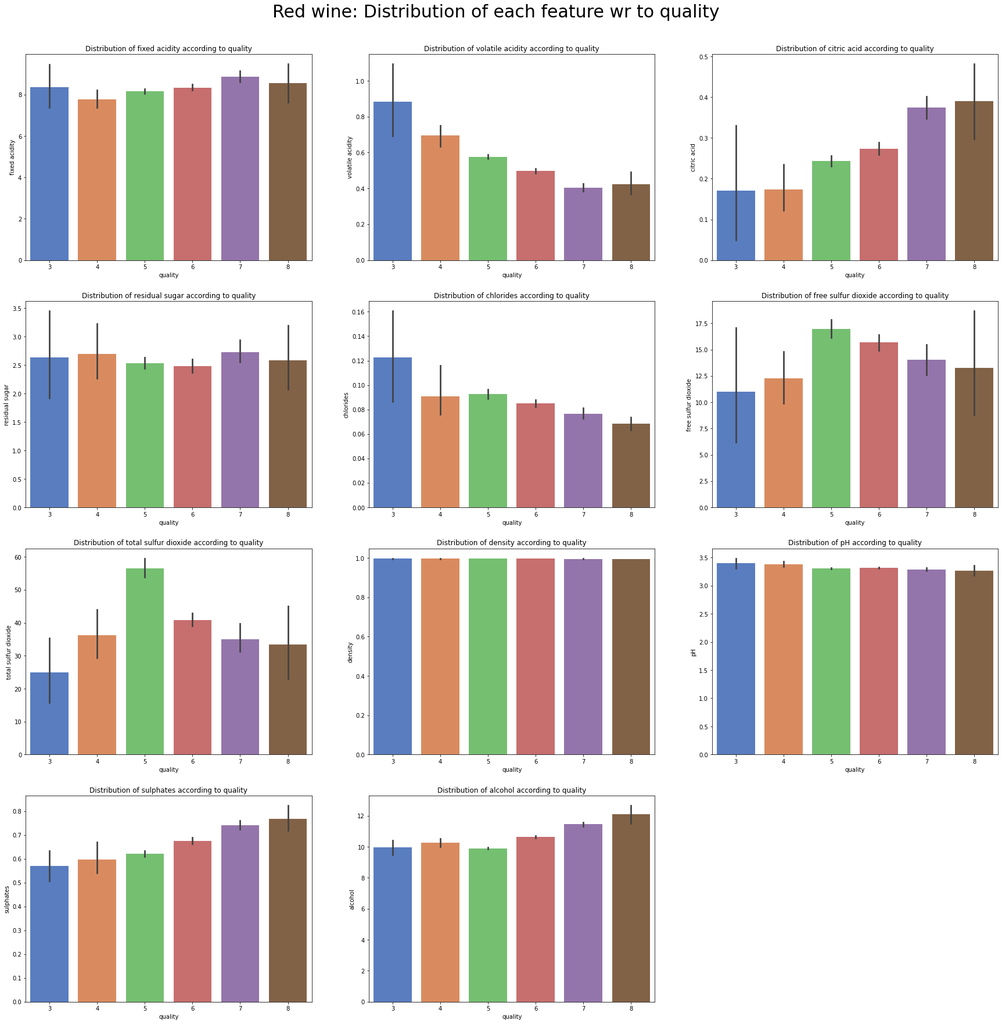

```python
fig = plt.figure(figsize = (30,30))
for i in range(11):
    plt.subplot(4,3,i+1)
    sns.barplot(x = 'quality', y = redwine.columns[i], data = redwine, palette='muted')
    plt.title('Distribution of '+redwine.columns[i]+' according to quality')
fig.suptitle('Red wine: Distribution of each feature wr to quality', y=0.92, fontsize=30)
plt.show()
```

##### Comments

The histograms above allow us to extract various trends and information about each feature for the redwine dataset.

First there are some features that seem to be more or less similar or independent of quality. These features will not allow us to give any specification to classify the wine's quality. Fixed acidity, residual sugar, density, or pH. Also, free and total sulfur dioxide are low for good and bad wines and high for middle quality wines.

On the other hand, there are some features that seem to have a linear influence on the quality and will allow us to classify the wines by quality easily.

- Volatile acidity goes down with quality
- Citric acid goes up with quality
- Chlorides goes down with quality
- Sulphates goes up with quality
- Alcohol goes up with quality

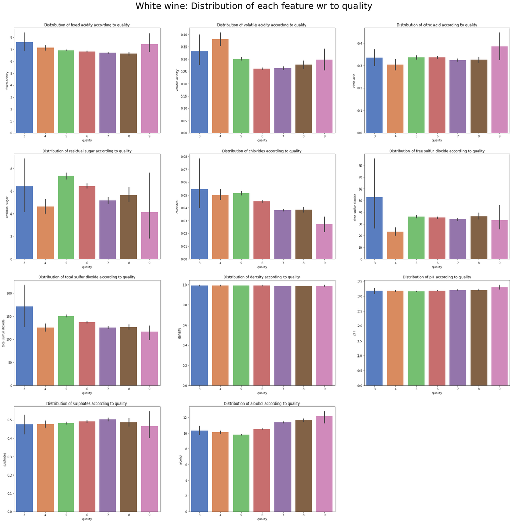

```python
fig = plt.figure(figsize = (30,30))
plt.title('White wine: Distribution of each feature wr to quality')
for i in range(11):
    plt.subplot(4,3,i+1)
    sns.barplot(x = 'quality', y = whitewine.columns[i], data = whitewine, palette='muted')
    plt.title('Distribution of '+whitewine.columns[i]+' according to quality')
fig.suptitle('White wine: Distribution of each feature wr to quality', y=0.92, fontsize=30)
plt.show()
```

##### Comments

The histograms above allow us to extract various trends and information about each feature for the whitewine dataset.

#### 1.4. Data preprocessing

Following the tip, we will divide our dataset into two different qualities, good and not good.

```python
redwine['good'] = redwine['quality'] > 6
redwine['good'] = redwine['good'].astype(int)

whitewine['good'] = whitewine['quality'] > 6
whitewine['good'] = whitewine['good'].astype(int)
```

```python
len(whitewine) - len(whitewine.dropna())
```

```
0
```

```python
redwine.head(10)
```

|  | fixed acidity | volatile acidity | citric acid | residual sugar | chlorides | free sulfur dioxide | total sulfur dioxide | density | pH | sulphates | alcohol | quality | good |
| --- | --- | --- | --- | --- | --- | --- | --- | --- | --- | --- | --- | --- | --- |
| 0 | 7.4 | 0.70 | 0.00 | 1.9 | 0.076 | 11.0 | 34.0 | 0.9978 | 3.51 | 0.56 | 9.4 | 5 | 0 |
| 1 | 7.8 | 0.88 | 0.00 | 2.6 | 0.098 | 25.0 | 67.0 | 0.9968 | 3.20 | 0.68 | 9.8 | 5 | 0 |
| 2 | 7.8 | 0.76 | 0.04 | 2.3 | 0.092 | 15.0 | 54.0 | 0.9970 | 3.26 | 0.65 | 9.8 | 5 | 0 |
| 3 | 11.2 | 0.28 | 0.56 | 1.9 | 0.075 | 17.0 | 60.0 | 0.9980 | 3.16 | 0.58 | 9.8 | 6 | 0 |
| 4 | 7.4 | 0.70 | 0.00 | 1.9 | 0.076 | 11.0 | 34.0 | 0.9978 | 3.51 | 0.56 | 9.4 | 5 | 0 |
| 5 | 7.4 | 0.66 | 0.00 | 1.8 | 0.075 | 13.0 | 40.0 | 0.9978 | 3.51 | 0.56 | 9.4 | 5 | 0 |
| 6 | 7.9 | 0.60 | 0.06 | 1.6 | 0.069 | 15.0 | 59.0 | 0.9964 | 3.30 | 0.46 | 9.4 | 5 | 0 |
| 7 | 7.3 | 0.65 | 0.00 | 1.2 | 0.065 | 15.0 | 21.0 | 0.9946 | 3.39 | 0.47 | 10.0 | 7 | 1 |
| 8 | 7.8 | 0.58 | 0.02 | 2.0 | 0.073 | 9.0 | 18.0 | 0.9968 | 3.36 | 0.57 | 9.5 | 7 | 1 |
| 9 | 7.5 | 0.50 | 0.36 | 6.1 | 0.071 | 17.0 | 102.0 | 0.9978 | 3.35 | 0.80 | 10.5 | 5 | 0 |

```python
whitewine.head(10)
```

|  | fixed acidity | volatile acidity | citric acid | residual sugar | chlorides | free sulfur dioxide | total sulfur dioxide | density | pH | sulphates | alcohol | quality | good |
| --- | --- | --- | --- | --- | --- | --- | --- | --- | --- | --- | --- | --- | --- |
| 0 | 7.0 | 0.27 | 0.36 | 20.7 | 0.045 | 45.0 | 170.0 | 1.0010 | 3.00 | 0.45 | 8.8 | 6 | 0 |
| 1 | 6.3 | 0.30 | 0.34 | 1.6 | 0.049 | 14.0 | 132.0 | 0.9940 | 3.30 | 0.49 | 9.5 | 6 | 0 |
| 2 | 8.1 | 0.28 | 0.40 | 6.9 | 0.050 | 30.0 | 97.0 | 0.9951 | 3.26 | 0.44 | 10.1 | 6 | 0 |
| 3 | 7.2 | 0.23 | 0.32 | 8.5 | 0.058 | 47.0 | 186.0 | 0.9956 | 3.19 | 0.40 | 9.9 | 6 | 0 |
| 4 | 7.2 | 0.23 | 0.32 | 8.5 | 0.058 | 47.0 | 186.0 | 0.9956 | 3.19 | 0.40 | 9.9 | 6 | 0 |
| 5 | 8.1 | 0.28 | 0.40 | 6.9 | 0.050 | 30.0 | 97.0 | 0.9951 | 3.26 | 0.44 | 10.1 | 6 | 0 |
| 6 | 6.2 | 0.32 | 0.16 | 7.0 | 0.045 | 30.0 | 136.0 | 0.9949 | 3.18 | 0.47 | 9.6 | 6 | 0 |
| 7 | 7.0 | 0.27 | 0.36 | 20.7 | 0.045 | 45.0 | 170.0 | 1.0010 | 3.00 | 0.45 | 8.8 | 6 | 0 |
| 8 | 6.3 | 0.30 | 0.34 | 1.6 | 0.049 | 14.0 | 132.0 | 0.9940 | 3.30 | 0.49 | 9.5 | 6 | 0 |
| 9 | 8.1 | 0.22 | 0.43 | 1.5 | 0.044 | 28.0 | 129.0 | 0.9938 | 3.22 | 0.45 | 11.0 | 6 | 0 |

Below, we check the distribution of the quality, and of the binary label created good.

Also, we made the choice to keep both databases separated, it seems more relevant: to determine the quality of a wine according to its chemical characteristics would require the knowledge of its type.

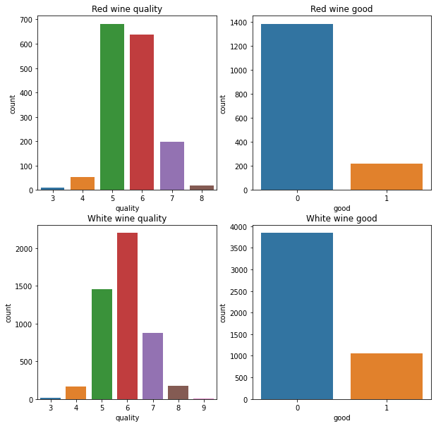

```python
fig = plt.figure(figsize=(10,10))

plt.subplot(2,2,1)
sns.countplot(redwine['quality'])
plt.title("Red wine quality")

plt.subplot(2,2,2)
sns.countplot(redwine['good'])
plt.title("Red wine good")

plt.subplot(2,2,3)
sns.countplot(whitewine['quality'])
plt.title("White wine quality")

plt.subplot(2,2,4)
sns.countplot(whitewine['good'])
plt.title("White wine good")

plt.show()
```

```python
redwine['good'].value_counts()
```

```
0    1382
1     217
Name: good, dtype: int64
```

```python
whitewine['good'].value_counts()
```

```
0    3838
1    1060
Name: good, dtype: int64
```

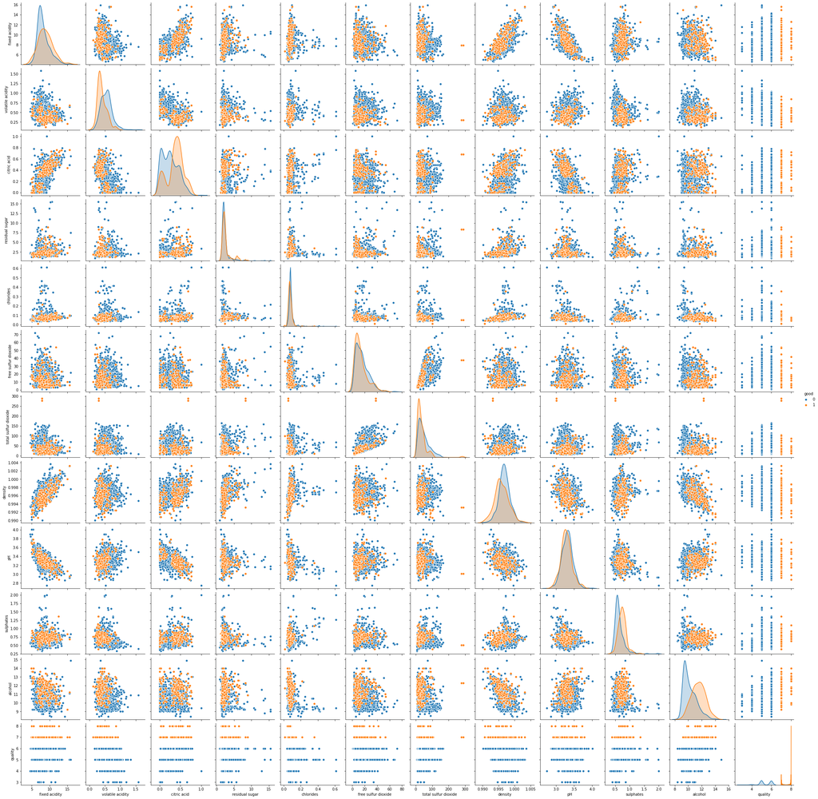

```python
import seaborn as sns
# Create the default pairplot
sns.pairplot(redwine, hue = 'good')
```

```python
#We drop the column quality

redwine = redwine.drop('quality', axis=1)

whitewine = whitewine.drop('quality', axis=1)
```

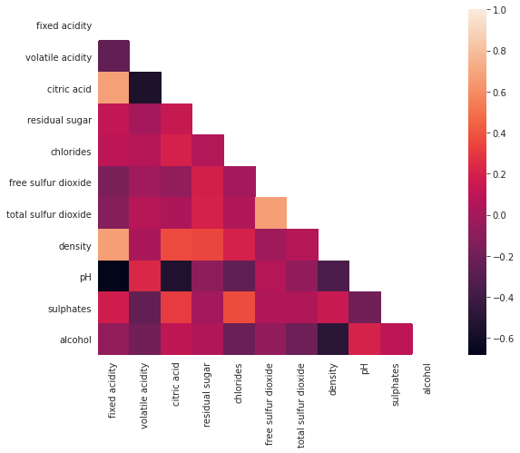

```python
fig = plt.figure(1, figsize=(10,7))
correlation_matrix = redwine.drop('good', axis=1).corr()
mask = np.zeros_like(correlation_matrix)
mask[np.triu_indices_from(mask)] = True
with sns.axes_style("white"):
    ax = sns.heatmap(correlation_matrix, mask=mask, square=True)
```

```python
#We separate the dataset into X and y and then into train and test sets

Xred = redwine.drop('good', axis=1)
yred = redwine['good']

Xwhite = whitewine.drop('good', axis=1)
ywhite = whitewine['good']
```

```python
X1 = Xred
target1 = yred

X2 = Xwhite
target2 = ywhite
```

Now, we'll apply a RFECV method (Recursive Feature Elimination) using Random Forest Classifier as a model, in order to determine which are the most important features, and if they are similar for both datasets.

```python
from sklearn.feature_selection import RFECV
from sklearn.model_selection import StratifiedKFold
from sklearn.ensemble import RandomForestClassifier
from sklearn.metrics import log_loss

rfc = RandomForestClassifier()
rfecv = RFECV(estimator=rfc, step=1, cv=StratifiedKFold(10), scoring='neg_log_loss')
rfecv.fit(X2, target2)

rfecv1 = RFECV(estimator=rfc, step=1, cv=StratifiedKFold(10), scoring='neg_log_loss')
rfecv1.fit(X1, target1)
```

```
RFECV(cv=StratifiedKFold(n_splits=10, random_state=None, shuffle=False),
      estimator=RandomForestClassifier(bootstrap=True, ccp_alpha=0.0,
                                       class_weight=None, criterion='gini',
                                       max_depth=None, max_features='auto',
                                       max_leaf_nodes=None, max_samples=None,
                                       min_impurity_decrease=0.0,
                                       min_impurity_split=None,
                                       min_samples_leaf=1, min_samples_split=2,
                                       min_weight_fraction_leaf=0.0,
                                       n_estimators=100, n_jobs=None,
                                       oob_score=False, random_state=None,
                                       verbose=0, warm_start=False),
      min_features_to_select=1, n_jobs=None, scoring='neg_log_loss', step=1,
      verbose=0)
```

```python
print('Optimal number of features for whitewine: {}'.format(rfecv.n_features_))
print('Optimal number of features for redwine: {}'.format(rfecv1.n_features_))
```

```
Optimal number of features for whitewine: 11
Optimal number of features for redwine: 7
```

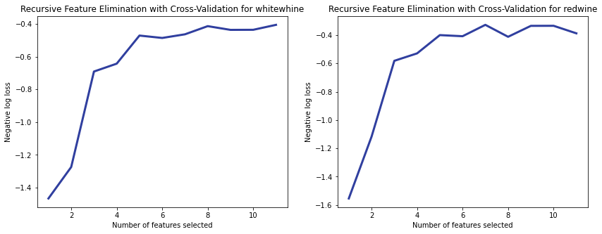

```python
plt.figure(figsize=(14, 5))

plt.subplot(1,2,1)
plt.title('Recursive Feature Elimination with Cross-Validation for whitewhine', fontsize=12)
plt.xlabel('Number of features selected')
plt.ylabel('Negative log loss')
plt.plot(range(1, len(rfecv.grid_scores_) + 1), rfecv.grid_scores_, color='#303F9F', linewidth=3)

plt.subplot(1,2,2)
plt.title('Recursive Feature Elimination with Cross-Validation for redwine', fontsize=12)
plt.xlabel('Number of features selected')
plt.ylabel('Negative log loss')
plt.plot(range(1, len(rfecv1.grid_scores_) + 1), rfecv1.grid_scores_, color='#303F9F', linewidth=3)

plt.show()
```

```python
# we drop the features that are less important, in order then to visualize them by importance
X1.drop(X1.columns[np.where(rfecv1.support_ == False)[0]], axis=1, inplace=True)
X2.drop(X2.columns[np.where(rfecv.support_ == False)[0]], axis=1, inplace=True)
```

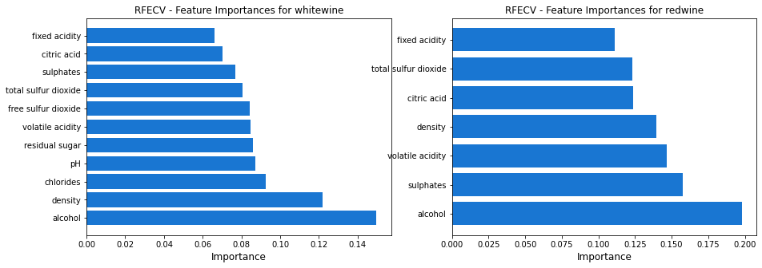

```python
dset = pd.DataFrame()
dset['attr'] = X2.columns
dset['importance'] = rfecv.estimator_.feature_importances_

dset = dset.sort_values(by='importance', ascending=False)

dset1 = pd.DataFrame()
dset1['attr'] = X1.columns
dset1['importance'] = rfecv1.estimator_.feature_importances_

dset1 = dset1.sort_values(by='importance', ascending=False)

plt.figure(figsize=(15, 5))
plt.subplot(1,2,1)
plt.barh(y=dset['attr'], width=dset['importance'], color='#1976D2')
plt.title('RFECV - Feature Importances for whitewine', fontsize=12)
plt.xlabel('Importance', fontsize=12)

plt.subplot(1,2,2)
plt.barh(y=dset1['attr'], width=dset1['importance'], color='#1976D2')
plt.title('RFECV - Feature Importances for redwine', fontsize=12)
plt.xlabel('Importance', fontsize=12)
plt.show()
```

We can choose to keep the features displayed above for each dataset.

```python
Xred_train, Xred_test, yred_train, yred_test = train_test_split(Xred, yred, test_size = 0.2, random_state = 42)

Xwhite_train, Xwhite_test, ywhite_train, ywhite_test = train_test_split(Xwhite, ywhite, test_size = 0.2, random_state = 42)
```

```python
#We normalize our features
sc = StandardScaler()

Xred_train = sc.fit_transform(Xred_train)
Xred_test = sc.fit_transform(Xred_test)

Xwhite_train = sc.fit_transform(Xred_train)
Xwhite_test = sc.fit_transform(Xred_test)
```

```python
from sklearn.decomposition import PCA

Xredpca = redwine.drop('good', axis=1)

pca = PCA(n_components=5)
pca.fit(Xredpca)
X_pca = pca.transform(Xredpca)
print("transformed shape:", X_pca.shape)

Xpcared_train, Xpcared_test, ypcared_train, ypcared_test = train_test_split(X_pca, yred, test_size = 0.2, random_state = 42)
```

```
transformed shape: (1599, 5)
```

```python
['Volatile acidity', 'Citric acid', 'Chlorides', 'Sulphates', 'Alcohol']
```

```
['Volatile acidity', 'Citric acid', 'Chlorides', 'Sulphates', 'Alcohol']
```

#### Model Selection

```python
from sklearn.linear_model import LogisticRegression

clf = LogisticRegression(random_state=0).fit(Xred_train, yred_train)
pred_pred_test = clf.predict_proba(Xred_test)
pred_pred_train = clf.predict_proba(Xred_train)

clf.score(Xred_train,yred_train)
```

```
0.890539483971853
```

$\mathcal{L} = - \frac{1}{N} \sum_{i=1}^{N} y_i \log(p_i) + (1-y_i) \log(1-p_i)$

where yi is the true (but withheld) quality outcome for wine i in the test data set, and pi is the predicted probability of good quality for wine i . Larger values of $\mathcal{L}$ indicate poorer predictions. Your goal then is to minimize the "Log Loss".

```python
from sklearn.metrics import log_loss
log_loss(yred_test, pred_pred_test)
```

```
0.2897130902783456
```

```python
log_loss(yred_train, pred_pred_train)
```

```
0.27590263134057386
```

```python
clf.score(Xred_train, yred_train)
```

```
0.890539483971853
```

```python
clf.score(Xred_test, yred_test)
```

```
0.871875
```

```python
from sklearn import svm

model_svm = svm.SVC()
model_svm.fit(Xred_train, yred_train)

#model_svm.predict([[2., 2.]])

model_svm.score(Xred_test, yred_test)
```

```
0.875
```

```python
from sklearn.gaussian_process import GaussianProcessClassifier
from sklearn.gaussian_process.kernels import RBF

kernel = 1.0 * RBF(1.0)
gpc = GaussianProcessClassifier(kernel=kernel, random_state=0).fit(Xred_train, yred_train)
yred_test_pred_gaussian = gpc.predict(Xred_test)
```

```python
log_loss(yred_test, yred_test_pred_gaussian)
```

```
4.641170566743847
```

```python
clf_red = LogisticRegression(random_state=0)
clf_red.fit(Xred_train, yred_train)

yred_test_pred_logistic = clf_red.predict(Xred_test)
```

```python
from sklearn.metrics import roc_curve, auc

fpr, tpr, _ = roc_curve(yred_test, yred_test_pred_gaussian)
roc_auc = auc(fpr, tpr)
```

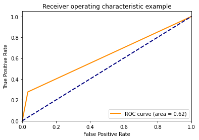

```python
plt.figure()
lw = 2
plt.plot(fpr, tpr, color='darkorange',
         lw=lw, label='ROC curve (area = %0.2f)' % roc_auc)
plt.plot([0, 1], [0, 1], color='navy', lw=lw, linestyle='--')
plt.xlim([0.0, 1.0])
plt.ylim([0.0, 1.05])
plt.xlabel('False Positive Rate')
plt.ylabel('True Positive Rate')
plt.title('Receiver operating characteristic example')
plt.legend(loc="lower right")
plt.show()
```

```python
from sklearn.metrics import confusion_matrix
```

```python
yred_test.unique().tolist()
```

```
[0, 1]
```

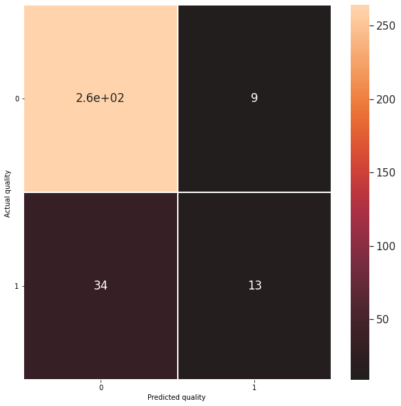

```python
cm = confusion_matrix(yred_test.values, yred_test_pred_gaussian)

fig, ax = plt.subplots(figsize=(10,10))         # Sample figsize in inches
sns.set(font_scale=1.4)
sns.heatmap(cm, annot=True, linewidths=.5, ax=ax, center=True)
ax.set_yticklabels(yred_test.unique().tolist(), rotation=0)
ax.set_xticklabels(yred_test.unique().tolist())
plt.xlabel('Predicted quality ')
plt.ylabel('Actual quality ')
```

```python
rfcred = RandomForestClassifier(random_state=42)
rfcwhite = RandomForestClassifier(random_state=42)


# Number of trees in random forest
n_estimators = [100]
# Maximum number of levels in tree
max_depth = [13, 14]
# Minimum number of samples required to split a node
min_samples_split = [2, 3]
# Minimum number of samples required at each leaf node
min_samples_leaf = [1, 2]
# Create the random grid
random_grid = {'n_estimators': n_estimators,
               'max_depth': max_depth,
               'min_samples_split': min_samples_split,
               'min_samples_leaf': min_samples_leaf}
```

```python
CV_rfcred = GridSearchCV(estimator=rfcred, param_grid=random_grid, cv=5, scoring='neg_log_loss')
CV_rfcwhite = GridSearchCV(estimator=rfcwhite, param_grid=random_grid, cv=5, scoring='neg_log_loss')
```

```python
CV_rfcred.fit(Xred_train, yred_train)
```

```
GridSearchCV(cv=5, error_score=nan,
             estimator=RandomForestClassifier(bootstrap=True, ccp_alpha=0.0,
                                              class_weight=None,
                                              criterion='gini', max_depth=None,
                                              max_features='auto',
                                              max_leaf_nodes=None,
                                              max_samples=None,
                                              min_impurity_decrease=0.0,
                                              min_impurity_split=None,
                                              min_samples_leaf=1,
                                              min_samples_split=2,
                                              min_weight_fraction_leaf=0.0,
                                              n_estimators=100, n_jobs=None,
                                              oob_score=False, random_state=42,
                                              verbose=0, warm_start=False),
             iid='deprecated', n_jobs=None,
             param_grid={'max_depth': [13, 14], 'min_samples_leaf': [1, 2],
                         'min_samples_split': [2, 3], 'n_estimators': [100]},
             pre_dispatch='2*n_jobs', refit=True, return_train_score=False,
             scoring='neg_log_loss', verbose=0)
```

```python
CV_rfcred.best_params_
```

```
{'max_depth': 14,
 'min_samples_leaf': 1,
 'min_samples_split': 2,
 'n_estimators': 100}
```

```python
rfcred_result = CV_rfcred.best_estimator_
rfcred_result.fit(Xred_train, yred_train)
```

```
RandomForestClassifier(bootstrap=True, ccp_alpha=0.0, class_weight=None,
                       criterion='gini', max_depth=14, max_features='auto',
                       max_leaf_nodes=None, max_samples=None,
                       min_impurity_decrease=0.0, min_impurity_split=None,
                       min_samples_leaf=1, min_samples_split=2,
                       min_weight_fraction_leaf=0.0, n_estimators=100,
                       n_jobs=None, oob_score=False, random_state=42, verbose=0,
                       warm_start=False)
```

```python
yred_train_pred_rfc = rfcred_result.predict(Xred_train)
accred__train_rfc = rfcred_result.score(Xred_train,yred_train)
loglossred_train_rfc = log_loss(yred_train, yred_train_pred_rfc)

yred_test_pred_rfc = rfcred_result.predict(Xred_test)
accred__test_rfc = rfcred_result.score(Xred_test, yred_test)
loglossred_test_rfc = log_loss(yred_test, yred_test_pred_rfc)



print("RANDOM FOREST CLASSIFIER RESULTS FOR THE REDWINE DATASET")
print("The training accuracy is: "+ str(accred__train_rfc))
print("The testing accuracy is: "+ str(accred__test_rfc))
print("The training logloss is " + str(loglossred_train_rfc))
print("The testing logloss is " + str(loglossred_test_rfc))
```

```
RANDOM FOREST CLASSIFIER RESULTS FOR THE REDWINE DATASET
The training accuracy is: 1.0
The testing accuracy is: 0.859375
The training logloss is 9.992007221626413e-16
The testing logloss is 4.857047914179917
```